# Challenge

In today's challenge, you will use what you know about the first law of thermodynamics to analyze the draining tank system. You will build a model for tank height using the disciplined process introduced in Reading 09.

As in Reading 09, you will need to scope the system. Then, you may need to break the system into components, and look at how energy flows in the form of power ($\dot{W}$,$\dot{Q}$,$\dot{E}_m$) between elements, and eventually out of the system. As before, getting a model for the system is about writing the first law for each element in the system, and then connecting the elements together using knowledge about how they transfer energy to one another.

To get you started, we will look at what we might be able to say about *the tank by itself* and *the valve by itself* to give you what you need to do a first law analysis of the system, which will mean using the first law analysis of each component, and looking at how the components transfer energy between one another, and eventually to the outside environment. Doing this will allow you to derive your input-output model.

Below, you can find a reminder about our disciplined process for model construction.

# Disciplined Process for Model Construction for a dynamic system using the first law of thermodynamics

After completing steps 1 and 2 of our overall process for model construction, you will have a list of independent and dependent variables. To use the conservation of energy to relate the two sets of variables and obtain your final model, you can:

1. Draw an energetic diagram for each element in your model scope, crossing off any terms you are assuming to be insignificant. When you do this, *justify* each assumption clearly in writing. Making an assumption is always a deliberate risk; the model evaluation step of our overall disciplined process for ES103 will guide you in determining the quality of the assumptions you make.
2. Write the time-derivative of the first law of thermodynamics for each element to describe how the element transfers energy between itself and its surroundings. Take care to substitute what you know about the energy, work, and heat terms for each element into the equation.
3. Write equations that indicate how each element in your scope exchanges energy between itself and other elements in the scope, or between itself and the overall system's surroundings. Use physical connections between elements in your system to guide you here.
4. Using algebraic manipulation, combine your equations from steps 2 and 3 to obtain a final system model.
5. Check your final system model for internal validity, including the signs and units of each term, and the overall form of the equation.

We will start with step 1 of this process to understand how the tank (one of the elements you may want to include in your scope) will act on its own.

# Challenge Continued

## First Law Analyis of a filled tank

To understand how the tank-valve *system* exchanges energy with its environment, let's first look at how the tank might act "on its own" without a valve, but with the possibility to somehow gain or lose water. As usual, we can write the first law in power form, which describes how the *stored* energy in the tank changes over time.

$$ \dot{E} = \dot{W}_{in} - \dot{W}_{out} + \dot{Q}_{in} - \dot{Q}_{out}+ \dot{E}_{m,in} - \dot{E}_{m,out}$$

This is drawn as an energetic diagram below.

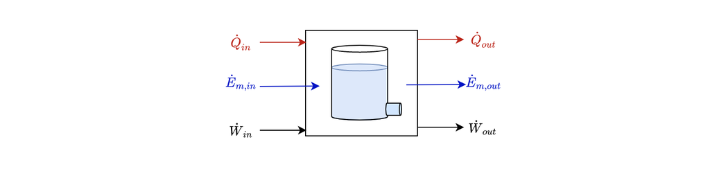

So what do we know about the tank? Does it store energy at all? Is there work done on it from the outside world? Does it do work on its environment?

To answer these questions, we should first start with the left-hand side of the first law equation. We know from observation that the tank initially has water in it, and then the water is gone. This is fundamentally different from our toy truck, where the truck's mass never changed! But we can still make certain, careful statements about the conservation of energy in the tank problem.

What we know is that the water in the tank *left*. This means that *some* transfer of energy must have happened to motivate this change. As far as we know, no invisible wizard imparted work on the water in the tank during the experiment. There was no "external input" after the experiment began... so it stands to reason that somehow, the tank had energy "stored" in it before we even began.

It's true that the only type of "stored energy" we talked about in Reading 9 was the kinetic energy of a mass, but there certainly are *many* other types that may be relevant here (we will not list all of the possibilities!). It just doesn't seem like kinetic energy is **the** answer here, simply because the water was not moving when the tank began to drain! This seems to fly in the face of the idea that the tank was storing kinetic energy at the start of the experiment, so if the tank *did* store energy, it must have been in some other form. What form? Do we have to look deep into a college-level physics or thermodynamics textbook to begin to understand? Not this time, fortunately. You may have heard of *potential energy* in high school physics, and before we start looking for explanations that are totally new, let's revisit what a system having potential energy means.

Note that if we're wrong, and potential energy doesn't fully describe the phenomena we see during a model evaluation step, we can come back and refine our model construction later!

## Gravitational Potential Energy

Gravitational "potential energy" is defined by how much work gravity "could do" on an object. Consider the following drawing of a ball at the "top" and at the "bottom" of a hill, at two different energy states, 1 and 2.

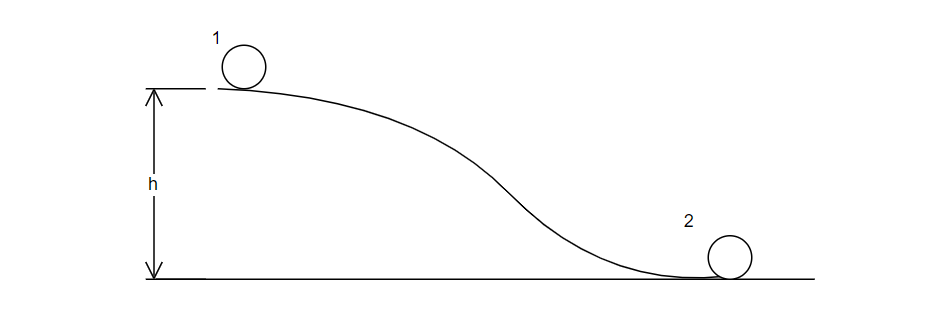

We know from Newton's second law that gravity will "pull" the ball down the slope. In doing so, gravity "does work" by applying its force on the ball over the distance its center of gravity moves. We find that the amount of work gravity can do on the ball is simply a function of the difference in height between where the ball started and our "zero reference point," or the bottom of the hill. Formally, gravitational potential energy can be written:

$$E_g = mgh$$

The height "h" is always a choice. It is possible to define it, for instance, from the center of the earth, but usually it is defined relative to a convenient plane of "zero" gravitational potential energy. "Zero" is in quotes there because it's not really zero... it's really just the place, in our system definition, where gravity can no longer do work on our system.

## First law analysis of a filled tank continued

Can we apply the concept of gravitational potential energy to our tank to help us fill out the $\dot{E}$ portion of our first law equation?

Well, the tank certainly does have **mass**, and we can calculate the mass of a fluid using density and volume:

$$m = \rho \mathcal{V}$$

where $\rho$ is density in $\frac{kg}{m^3}$. Fluids like water are often considered to be **incompressible**, which means their density is constant. We will make that assumption moving forward. Volume $\mathcal{V}$, for a tank *with a constant cross sectional area $A$*, is simply:

$$\mathcal{V} = A h$$

Now, if the density of the water's mass inside the tank is constant, we can say that its center of gravity lies at the geometric center of the water in the tank at any moment. This means that the height of the water's center of mass is located at:

$$h_g = \frac{h}{2}$$

A labeled drawing of the tank is presented below.

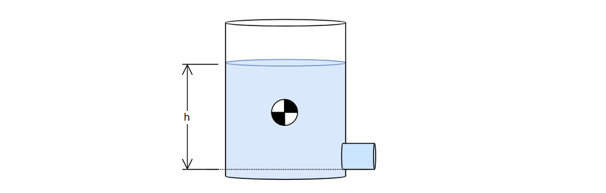

Given what we've discovered, we can write the **gravitational potential** energy in the tank as:

$$E_{g} = \rho g A h h_g = \rho g A \frac{h^2}{2}$$

But before we move on, is there any other energy the tank might store? The tank of water is at room temperature, and remains so for the duration of the experiment, so it's unlikely that there would be any kind of "thermal energy" stored in there that could be transferred, even as a mass of water leaves the tank. There are no chemical reactions (that we know of) that are occurring. There might be some kinetic energy associated with the CG of the water moving as the height drops, but in our experiment, the height **drops incredibly slowly**, so we can likely ignore stored kinetic energy as well.

If we ignore all of these possible sources of stored energy, **knowing that if we're wrong to ignore them, model evaluation should tell us we need to come back to these assumptions**, then we can write the derivative of stored energy in the tank as:

$$\dot{E} = \rho A g h \dot{h}$$

and we have one term nailed down in our first law equation. This leaves us with:

$$\dot{E} = \rho A g h \dot{h} = \dot{W}_{in} - \dot{W}_{out} + \dot{Q}_{in} - \dot{Q}_{out} + \dot{E}_{m,in,tank} - \dot{E}_{m,out,tank}$$

So moving on to the right-hand side of the equation, what do we know about work done either on or by the tank? What do we even mean by work in this context? Does the mass leaving the tank carry any significant energy with it?

Work, for fluids, is still mechanical work! Work can be done on a fluid by changing the geometry of its container (think about squishing a balloon), by moving it around with a pump or other mechanical device, or by "pushing" fluid from one place to another, creating "flow." This last type of work is what we'll focus on, since none of the others seem to apply to our problem. To understand it, we need to understand pressure.

## Pressure in a fluid

Because fluids conform to their surroundings, the idea of a force applied at a "point" is less useful for fluids than it is for solid bodies. When we talk about fluids, we usually talk about pressure. Pressure is defined as *normal force* per unit area. This applies to solid bodies as well, but pressure is a key concept in the study of how fluids move (or don't). If $F$ is force normal to the surface of an arbitrary "fluid element" with area $A$, the pressure applied to that surface is defined as:

$$P = \frac{F}{A}$$

In SI units, pressure has units of $\frac{N}{m^2}$, which is also called a "Pascal," abbreviated $Pa$.

Pressure in a fluid is usually measured as a difference from *atmospheric* pressure. This is called "gauge pressure." Gauge pressure is different from "absolute pressure," which is measured relative to a perfect vacuum.

To understand what the pressure in our tank of water is, we need to go a step further and discuss a special kind of pressure: hydrostatic pressure.

## Hydrostatic Pressure

If you have ever been in a pool, you probably know that when you dive deep, you feel increased pressure on your eardrums. Why is this? Well, if we were to look at a rectangular prismatic "chunk" of fluid, also called a "fluid element" with a width $\Delta x$, a height $\Delta z$, and a thickness into the page of $\Delta y$, we could draw its free body diagram as follows:

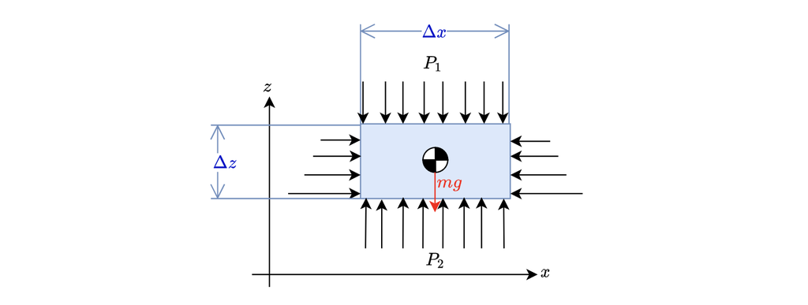

The gravitational force on this fluid element is $mg$, where mass $m$ can be calculated from the volume of the chunk multiplied by its density $\rho$. This means:

$$ mg = \rho \mathcal{V} g$$

Where $V = \Delta x \Delta y \Delta z$. If we imagine that the element is in equillibrium, we could actually write Newton's second law for it in the z-direction.

$$\sum F_z = P_2 \Delta x \Delta y - P_1 \Delta x \Delta y - \rho \Delta x \Delta y \Delta z g = 0$$

After cancaling $\Delta x \Delta y$ from all terms, we can see that:

$$P_2 - P_1 = \rho g \Delta z$$

This means that the pressure in a fluid increases linearly with depth, which leads to the standard equation for hydrostatic pressure expressed as a *gauge pressure*, meaning $P_{atm}=0$:

$$P_2-P_1 = P - P_{atm} = P = \rho g h$$

This pressure is related to our tank's *potential energy*. The hydrostatic pressure at the bottom of the tank is what ultimately motivates water to leave the tank when there is a way out, through a phenomenon called *flow work.*

## Work done via fluid flow

Like moving a solid body, moving a fluid takes work. Our definition of mechanical work was:

$$W = \int \vec{F} \cdot d\vec{s}$$

In a fluid, pressure is defined as force normal to a fluid surface per unit area. If a fluid flows through a thin "slice" of pipe, perhaps with thickness $dx$ and cross sectional area $A$, we can say that the work done in pushing fluid through this section of pipe could be written:

$$W = P A dx = P \mathcal{V}$$

where $W$ represents work, $P$ represents a pressure, and $\mathcal{V}$ represents a swept volume through which the fluid is moved.

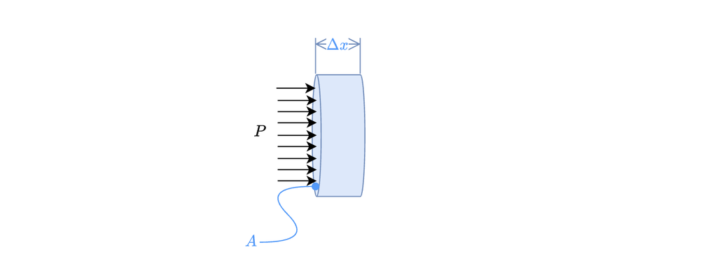

If we take the time derivative of this expression, we can get an expression for the *power* that is expended when moving a fluid at a certain flow rate using a certain pressure.

$$\dot{W} = P\dot{\mathcal{V}}$$

where $\dot{\mathcal{V}}$ is the *volumetric flow rate* of the fluid, expressed in SI units of $\frac{m^3}{s}$.

## First law analysis of a filled tank continued

$$\require{cancel}$$

Now, revisiting our power-form first law equation for the tank, we had:

$$\dot{E} = \rho A g h \dot{h} = \dot{W}_{in} - \dot{W}_{out} + \dot{Q}_{in} - \dot{Q}_{out}+ \dot{E}_{m,in,tank} - \dot{E}_{m,out,tank}$$

Making the *assumption* that heat transfer is not important when considering the stored energy in the tank (given our idea about what type of energy the tank stores, this seems reasonable), we could try crossing out both heat transfer terms as insignificant.

Because mass crosses out of the tank's scope, we need to consider $\dot{E}_{m}$ terms in the first law. Our tank drains slowly, so we will assume that the fluid leaving it does not carry significant kinetic energy. The fluid leaves from the bottom of the tank, where potential energy has been defined to be zero by our height reference choice. Finally, the water leaving the tank, along with the water in the tank, is at room temperature, so the water leaving the tank carries no significant *internal* energy with it.

This leaves us with:

$$ \dot{E} = \dot{W}_{in} - \dot{W}_{out} + \cancel{\dot{Q}_{in}} - \cancel{\dot{Q}}_{out}+ \cancel{\dot{E}}_{m,in,tank} - \cancel{\dot{E}}_{m,out,tank}$$

We also now have a way to express work that might either fill the tank or empty it via *flow work.* We may not know, for a given scenario, whether the balance of this work is positive (filling) or negative (emptying). If the tank's energy goes down, and we know there is nothing in our system definition that could fill it, we may cross out $\dot{W}_{in}$. If we don't know the direction, we could be general and define $\dot{W}_{net} = \dot{W}_{in}-\dot{W}_{out}$. In this definition, if $\dot{W}_{net}>0$, the tank's stored energy will increase. If it is negative, meaning that the net flow power is *out* of the tank, its stored energy will decrease. Keeping things general leaves us with the following equation for a tank's change in energy:

$$\dot{E} = \rho A g h \dot{h} = \dot{W}_{net}$$

Where $\dot{W}_{net}$ is *flow work* into or out of the tank.

So what governs how much flow work is done as our fluid leaves the tank? You might have guessed that it's the valve!

## First Law Analysis of a valve

With the analysis of the tank complete, let's look at what the balance of energy flow might look like for the valve we opened to let the tank begin to drain. As usual, we start with a general form of the first law of thermodynamics:

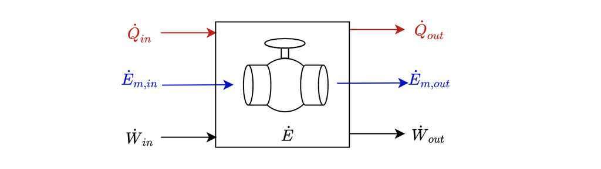

For the valve, we write:

$$\dot{E} = \dot{W}_{in} - \dot{W}_{out} + \dot{E}_{m,in} - \dot{E}_{m,out} + \dot{Q}_{in} - \dot{Q}_{out}$$

Beginning with the left-hand side of the equation, we are on the hunt for what types of energy could be stored inside the valve. If we assume that the valve is not tall enough to produce differences in gravitational potential energy (it certainly is much less tall than the tank), we can probably rule out potential energy. Further, if we look at what is actually *restricting* the flow in a valve, the actual volume of the adjustable piece of a needle valve (like the one on our tank) is very small. A blown-up representation of this is shown below.

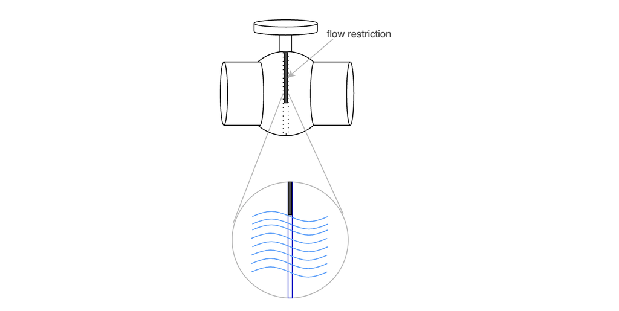

The actual portion of the valve that is restricting flow is so small that we might even say that there is *no significant volume* to the valve. If that's the case, we can say that the orifice that is restricting flow is very thin, and as such, there is no significant *mass* inside the valve at any time. If there is no significant mass inside the valve, there can be no significant *kinetic energy* either. If we also make the assumption that no other forms of energy can be stored in the valve (which again, we will need to justify with an experiment), then we could write:

$$E_{stored} = 0$$

If there is no stored energy inside the valve, then we can also write:

$$\dot{E} = 0$$

This reconfigures our first law equation to be:

$$ \cancel{\dot{E}} = \dot{W}_{in} - \dot{W}_{out} + \dot{Q}_{in} - \dot{Q}_{out}+ \dot{E}_{m,in} - \dot{E}_{m,out}$$

no significant mass inside the valve also means that $\dot{E}_{m}$ terms must drop out, which leaves us with:

$$\dot{W}_{in} - \dot{W}_{out} = \dot{Q}_{out} - \dot{Q}_{in}$$

.

In other words, the *net work* done on the valve is the negative of the *net heat transfer* in the valve. Like our bearing in Reading 9, the valve can only turn work into heat. It cannot store energy. If net work is done on the valve, we know that the first law tells us that energy must be transferred *out* of the valve via heat.

But what can we say about the left-hand side of our new equation, $\dot{W}_{in} - \dot{W}_{out}$?

Without fail, the inlet of a valve is at a higher pressure than the valve's outlet, because moving flow through a valve requires *work* to be done. So it is always true that a valve meeting our assumptions will have a higher pressure "upstream." We can represent the pressure at a valve's inlet and outlet using the picture below:

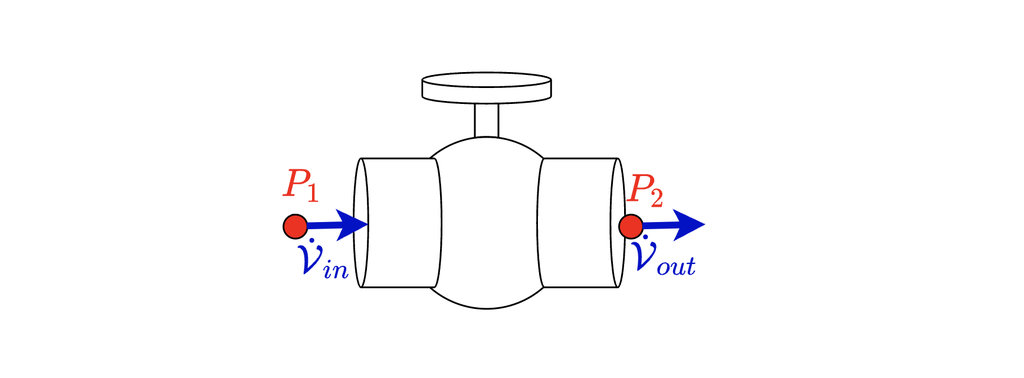

Using our definition of flow work, we can write our first law equation as:

$$\dot{W}_{in} - \dot{W}_{out} = P_1\dot{V}_{in} - P_2 \dot{\mathcal{V}}_{out} = -\dot{Q}_{net}$$

Where $\dot{Q}_{net} = \dot{Q}_{in}-\dot{Q}_{out}$.

Because the valve itself cannot accumulate mass (we said no significant mass was stored in it at all!), we know that $\dot{\mathcal{V}}_{in}=\dot{\mathcal{V}}_{out} = \dot{\mathcal{V}}$. This means we can re-write our first law equation as

$$\dot{W}_{in} - \dot{W}_{out} = (P_1 - P_2)\dot{V} = -\dot{Q}_{net}$$

As usual, the first law only tells us about the balance of work, heat, and energy in our system. It does not tell us *how much* flow work is needed to push a certain volumetric flow rate through it.

To answer this question, one could dive into a detailed study of fluid mechanics, but we will keep our discussion at the empirical level. Consider the video below, which shows syringes (whose outlets are a lot like little valves) subjected to different weights. Volume of the syringes is a constant $5ml$ for all tests in the video.

[video not shown]

Watching closely, one can see that a heavier mass on top of the syringe produces a shorter "emptying time," which equates to a higher flow rate, since average flow rate could be calculated for each experiment as $\frac{\Delta\mathcal{V}}{\Delta t}$.

A higher mass equates to a higher pressure exerted at the inlet of the valve. Ignoring any friction (good idea? bad idea?) from the syringe plunger, and ignoring the small change in hydrostatic pressure from the top of the syringe to the bottom, one could write that the pressure on the upstream side of the syringe outlet (valve) is $P_1 = \frac{mg}{A}$, where $A$ is the plunger area. Clearly, the larger the pressure, the larger the flow rate.

As it turns out, for many situations, a valve will have an approximately *linear* relationship between pressure difference $P_1-P_2$ and volumetric flow rate $\dot{V}$ through the valve. If you did many tests on syringes like the ones above, and plotted average flow rate as a function of pressure difference, you might find a plot that looks like this:

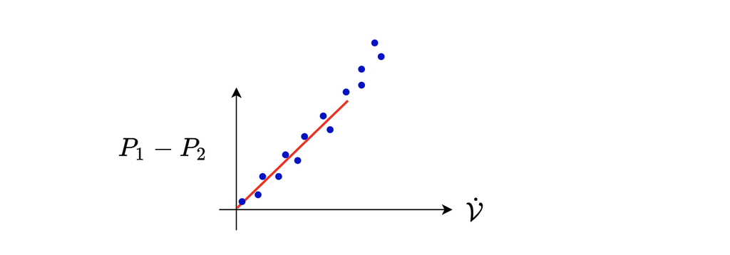

This leads to an *empirical* relationship between pressure and flow rate for a given valve at a given position, which is often written:

$$P_1 - P_2 = \dot{V}\cdot R$$

Where $R$ is the slope of the linear relationsihp. **Note: many fluid resistors only act linearly for small ranges of pressures and flow rates, but only for small ranges!** More sophisticated empirical (or analytical) relationships will often produce better results. It's also worth noting at this point how similar the valve's equation is to that of our *idealized damper* from Reading 07, $F_b = b(v_1-v_2)$.

In any case, we can now make a substitution in our first law equation using this empirical relationship, and it will tell us just how much power is required to move a certain amount of flow through a particular valve:

$$\dot{W}_{in} - \dot{W}_{out} = R\dot{V}^2 = -\dot{Q}_{net}$$

This can serve as our thermodynamic model of a valve. We do work on it by pushing fluid through it, and all of that work is turned into heat.

# Assignment

In this assignment, you will scope a model of the tank-valve system, and use the analyses of each *component* above to build a complete model of the tank as it drains. You should end up with a differential equation that has properties of the tank, the water, and the valve in it. Consider the tank height to be your system's output.

## Deliverables: System Scoping

Below, scope your system. Include both an energetic diagram representing the entire tank-valve system and the system broken up into constituent elements.

## Deliverables: Model Construction

Using the first law analyses of each component, and the thermodynamic relationships between componenets (power transferred from one to another), derive a differential equation that you can use to find the height in the tank as a function of time. The dimensions of the tank are a rectangular, with cross sectional dimensions of approximately $.075m$ by $.08m$. The value of the valve's resistance is unknown. Using the data file 'reading10data_squaretank.txt', which is data taken from the video below, determine the valve's *resistance* by implementing your model and adjusting the fluid resistance until the model fits. **Hint: use a small timestep, and note that fluid resistances are often very, very large** (upwards of $10^8 \frac{Pa\cdot s}{m^3}$ would not be unreasonable).

**Do not collect new data. Please read the paragraph above.**

[video not shown]

```matlab
% YOUR CODE HERE
error('No Answer Given!')
```

[output not shown]

## Deliverables: Model Evaluation

Now, let's look at what happens when the tank area changes, but **the same valve is attached**. this new tank, which is a Betta fish tank, has a rectangular cross section with dimensions of $24cm$ by $7.8cm$. A video of the tank draining through this valve is provided below, but note that you do not have to collect your own data. I have collected it for you, and it is in a file called 'reading10data_longtank.txt'. To see how your model generalizes, simulate this tank draining experiment using your model. **Do not re-adjust the fluid resistance value for the valve. Only change the tank area based on the dimensions I gave you.**

[video not shown]

```matlab
% YOUR CODE HERE
error('No Answer Given!')
```

[output not shown]

Below, comment on how well or how poorly your model generalized given your model evaluation work in the cell above. If there are disagreements, what physical phenomena do you think they are the result of? How well is each of our assumptions satisfied? Be specific, and show evidence for your claims if possible for full credit.